# 02-GLMM version 2024

Francisco E. Fonturbel, Guido Pavez

25/Jan/2025

## Anthropogenic effects on chungungo’s abundance

Here we will explore some anthropogenic variables as potential drivers of abundance change on this species

Let’s do some nice ggplots to examine our data before fitting fancy models:

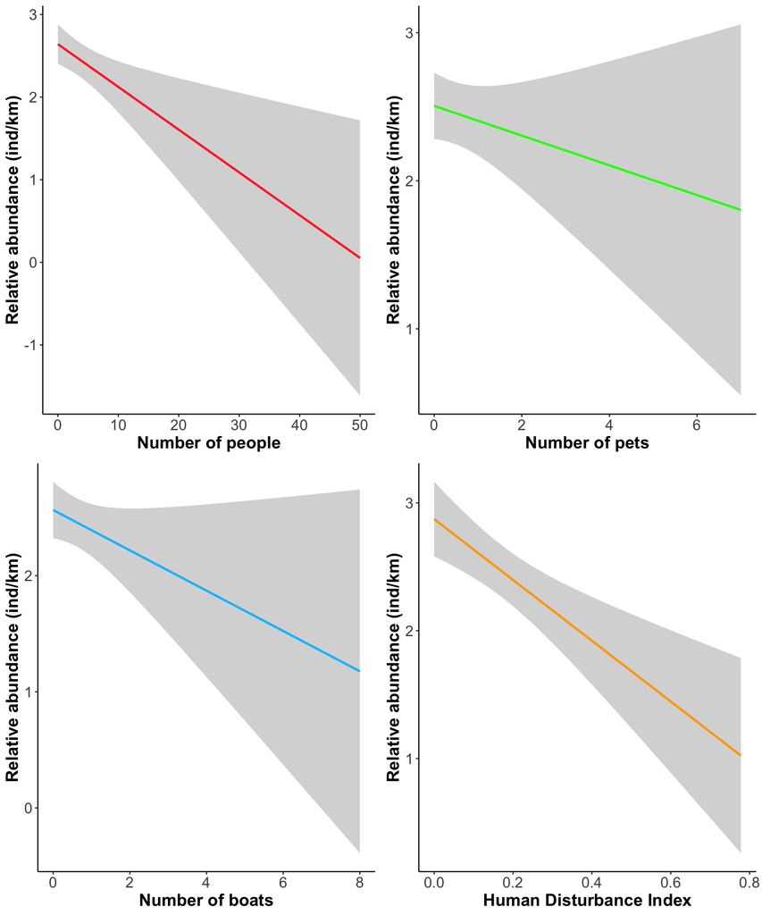

##How is our **response varible** distributed?

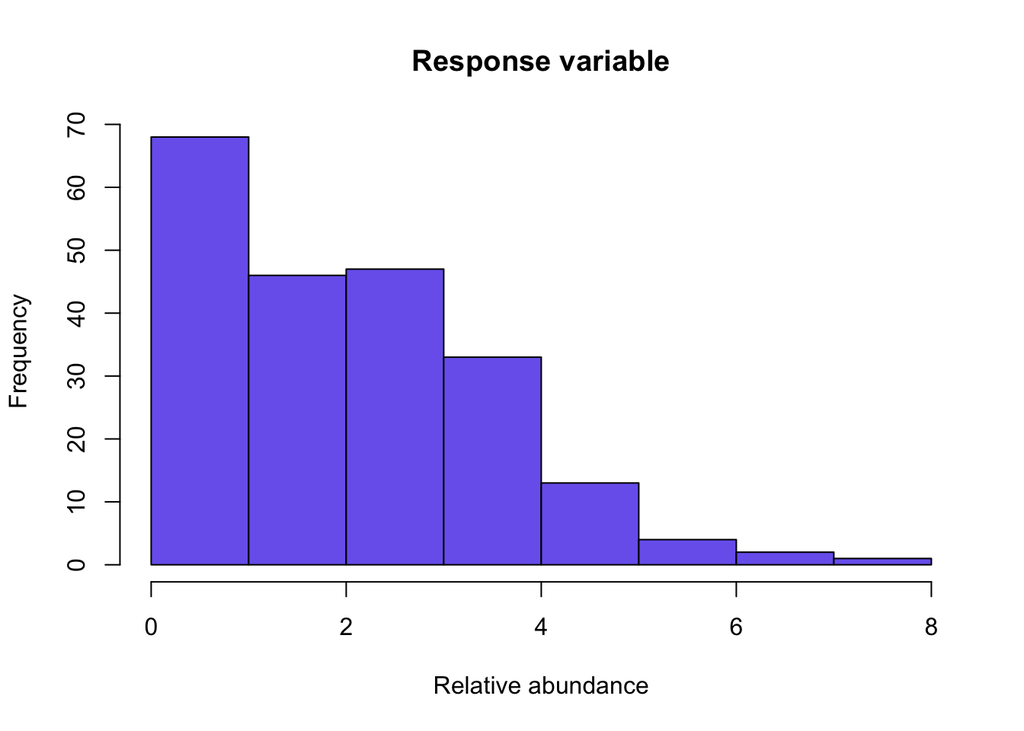

Well, our response variable is not normal, as abundance is a count variable with positive integers. Therefore, we should use *Poisson* or *negative binomial* distributions instead.

## Models

To do this, we will use a Poisson GLMM, using sampling site as random factor.

```
## Generalized linear mixed model fit by maximum likelihood (Laplace
##   Approximation) [glmerMod]
##  Family: poisson  ( log )
## Formula: abund ~ people + boats + pets + (1 | site)
##
##      AIC      BIC   logLik deviance df.resid
##    723.7    740.5   -356.8    713.7      209
##
## Scaled residuals:
##     Min      1Q  Median      3Q     Max
## -1.4998 -0.5358 -0.1823  0.5212  3.3401
##
## Random effects:
##  Groups Name        Variance Std.Dev.
##  site   (Intercept) 0.1733   0.4162
## Number of obs: 214, groups:  site, 6
##
## Fixed effects:
##             Estimate Std. Error z value Pr(>|z|)
## (Intercept)  0.83293    0.18146   4.590 4.43e-06 ***
## people      -0.01718    0.01086  -1.582    0.114
## boats        0.01080    0.05198   0.208    0.835
## pets         0.09194    0.05372   1.711    0.087 .
## ---
## Signif. codes:  0 '***' 0.001 '**' 0.01 '*' 0.05 '.' 0.1 ' ' 1
##
## Correlation of Fixed Effects:
##        (Intr) people boats
## people -0.096
## boats  -0.161 -0.130
## pets   -0.060 -0.542  0.116
```

No significant resuls here, but the results when we conduct a regular GLM without random factors:

```
##
## Call:
## glm(formula = abund ~ people + boats + pets, family = "poisson",
##     na.action = "na.fail")
##
## Coefficients:
##             Estimate Std. Error z value Pr(>|z|)
## (Intercept)  1.01168    0.05579  18.135   <2e-16 ***
## people      -0.02917    0.01138  -2.563   0.0104 *
## boats       -0.05971    0.04931  -1.211   0.2260
## pets         0.03025    0.04960   0.610   0.5419
## ---
## Signif. codes:  0 '***' 0.001 '**' 0.01 '*' 0.05 '.' 0.1 ' ' 1
##
## (Dispersion parameter for poisson family taken to be 1)
##
##     Null deviance: 236.43  on 213  degrees of freedom
## Residual deviance: 225.06  on 210  degrees of freedom
## AIC: 775.11
##
## Number of Fisher Scoring iterations: 5
```

Let’s use the disturbance index2 instead **this is what we reported in the ms**:

```
##
## Call:
## glm(formula = abund ~ index_2, family = "poisson", na.action = "na.fail")
##
## Coefficients:
##             Estimate Std. Error z value Pr(>|z|)
## (Intercept)  1.06924    0.06034  17.720  < 2e-16 ***
## index_2     -1.06003    0.28702  -3.693 0.000221 ***
## ---
## Signif. codes:  0 '***' 0.001 '**' 0.01 '*' 0.05 '.' 0.1 ' ' 1
##
## (Dispersion parameter for poisson family taken to be 1)
##
##     Null deviance: 236.43  on 213  degrees of freedom
## Residual deviance: 221.88  on 212  degrees of freedom
## AIC: 767.92
##
## Number of Fisher Scoring iterations: 5
```

Now we do find a coherent result!!! Awesome work Guido :-)

Let’s try some multi-model inference to examine the relative support of each variable to our dataset

```
## Global model call: glmer(formula = abund ~ people + boats + pets + (1 | site), family = "poisson",
##     na.action = "na.fail")
## ---
## Model selection table
##   (Intrc)     peopl   pets df   logLik   BIC delta weight
## 1  0.8239                   2 -358.607 727.9  0.00  0.831
## 5  0.8046           0.0417  3 -358.194 732.5  4.54  0.086
## 3  0.8498 -0.007625         3 -358.228 732.6  4.61  0.083
## Models ranked by BIC(x)
## Random terms (all models):
##   1 | site
```

[output not shown]

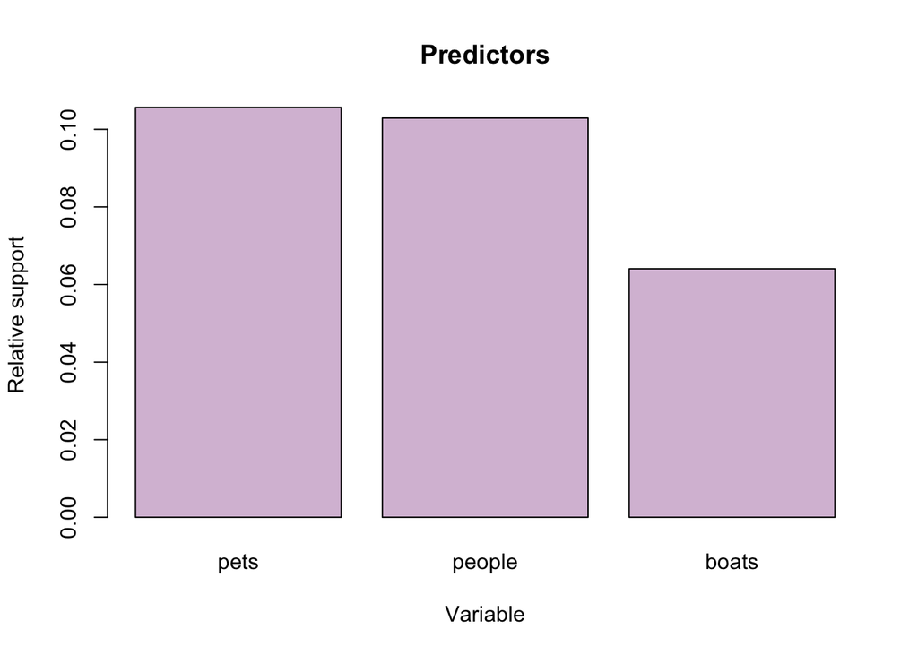

### A Bayesian approach

We’ll try now a Bayesian approach (based on Dimas’ code) to test the same but under a Bayesian framework based on Monte Carlo Markov Chains

```
##
##  Iterations = 3001:12991
##  Thinning interval  = 10
##  Sample size  = 1000
##
##  DIC: 711.9722
##
##  G-structure:  ~site
##
##      post.mean l-95% CI u-95% CI eff.samp
## site    0.2853  0.03168   0.7899    587.9
##
##  R-structure:  ~units
##
##       post.mean  l-95% CI u-95% CI eff.samp
## units 0.0007365 2.123e-05 0.003478    17.49
##
##  Location effects: abund ~ people + boats + pets
##
##             post.mean  l-95% CI  u-95% CI eff.samp  pMCMC
## (Intercept)  0.885787  0.404712  1.354302  767.270  0.006 **
## people      -0.021650 -0.036300 -0.007921    3.345 <0.001 ***
## boats       -0.015094 -0.062205  0.057568    4.350  0.524
## pets         0.122311  0.048161  0.190877    2.128 <0.001 ***
## ---
## Signif. codes:  0 '***' 0.001 '**' 0.01 '*' 0.05 '.' 0.1 ' ' 1
```